# **Problem Statement**

#### **Business Context**

Understanding customer personality and behavior is pivotal for businesses to enhance customer satisfaction and increase revenue. Segmentation based on a customer's personality, demographics, and purchasing behavior allows companies to create tailored marketing campaigns, improve customer retention, and optimize product offerings.

A leading retail company with a rapidly growing customer base seeks to gain deeper insights into their customers' profiles. The company recognizes that understanding customer personalities, lifestyles, and purchasing habits can unlock significant opportunities for personalizing marketing strategies and creating loyalty programs. These insights can help address critical business challenges, such as improving the effectiveness of marketing campaigns, identifying high-value customer groups, and fostering long-term relationships with customers.

With the competition intensifying in the retail space, moving away from generic strategies to more targeted and personalized approaches is essential for sustaining a competitive edge.

#### **Objective**

In an effort to optimize marketing efficiency and enhance customer experience, the company has embarked on a mission to identify distinct customer segments. By understanding the characteristics, preferences, and behaviors of each group, the company aims to:

1. Develop personalized marketing campaigns to increase conversion rates.
2. Create effective retention strategies for high-value customers.
3. Optimize resource allocation, such as inventory management, pricing strategies, and store layouts.

As a data scientist tasked with this project, your responsibility is to analyze the given customer data, apply machine learning techniques to segment the customer base, and provide actionable insights into the characteristics of each segment.

#### **Data Dictionary**

The dataset includes historical data on customer demographics, personality traits, and purchasing behaviors. Key attributes are:

1. **Customer Information**
   - **ID:** Unique identifier for each customer.
   - **Year_Birth:** Customer's year of birth.
   - **Education:** Education level of the customer.
   - **Marital_Status:** Marital status of the customer.
   - **Income:** Yearly household income (in dollars).
   - **Kidhome:** Number of children in the household.
   - **Teenhome:** Number of teenagers in the household.
   - **Dt_Customer:** Date when the customer enrolled with the company.
   - **Recency:** Number of days since the customer’s last purchase.
   - **Complain:** Whether the customer complained in the last 2 years (1 for yes, 0 for no).
2. **Spending Information (Last 2 Years)**
   - **MntWines:** Amount spent on wine.
   - **MntFruits:** Amount spent on fruits.
   - **MntMeatProducts:** Amount spent on meat.
   - **MntFishProducts:** Amount spent on fish.
   - **MntSweetProducts:** Amount spent on sweets.
   - **MntGoldProds:** Amount spent on gold products.
3. **Purchase and Campaign Interaction**
   - **NumDealsPurchases:** Number of purchases made using a discount.
   - **AcceptedCmp1:** Response to the 1st campaign (1 for yes, 0 for no).
   - **AcceptedCmp2:** Response to the 2nd campaign (1 for yes, 0 for no).
   - **AcceptedCmp3:** Response to the 3rd campaign (1 for yes, 0 for no).
   - **AcceptedCmp4:** Response to the 4th campaign (1 for yes, 0 for no).
   - **AcceptedCmp5:** Response to the 5th campaign (1 for yes, 0 for no).
   - **Response:** Response to the last campaign (1 for yes, 0 for no).
4. **Shopping Behavior**
   - **NumWebPurchases:** Number of purchases made through the company’s website.
   - **NumCatalogPurchases:** Number of purchases made using catalogs.
   - **NumStorePurchases:** Number of purchases made directly in stores.
   - **NumWebVisitsMonth:** Number of visits to the company’s website in the last month.

# **Let's start coding!**

## **Importing necessary libraries**

```python
# Libraries to help with reading and manipulating data
import pandas as pd
import numpy as np

# libaries to help with data visualization
import matplotlib.pyplot as plt
import seaborn as sns

# Removes the limit for the number of displayed columns
pd.set_option("display.max_columns", None)
# Sets the limit for the number of displayed rows
pd.set_option("display.max_rows", 200)

# to scale the data using z-score
from sklearn.preprocessing import StandardScaler

# to compute distances
from scipy.spatial.distance import cdist, pdist

# to perform k-means clustering and compute silhouette scores
from sklearn.cluster import KMeans
from sklearn.metrics import silhouette_score

# to visualize the elbow curve and silhouette scores
from yellowbrick.cluster import KElbowVisualizer, SilhouetteVisualizer

# to suppress warnings
import warnings

warnings.filterwarnings("ignore")
```

## **Loading the data**

```python
# uncomment and run the following line if using Google Colab
from google.colab import drive
drive.mount('/content/drive')
```

```python
# loading data into a pandas dataframe
data = pd.read_csv("/content/drive/MyDrive/MIT Course/Module 2: Unstructured Data/Project/Customer_Personality_Segmentation.csv", sep="\t")
```

## **Data Overview**

#### **Question 1**: What are the data types of all the columns?

```python
data.shape
```

[output not shown]

```python
# Write your code here.
data.info()
data.head()
```

```
<class 'pandas.core.frame.DataFrame'>
RangeIndex: 2240 entries, 0 to 2239
Data columns (total 29 columns):
 #   Column               Non-Null Count  Dtype
---  ------               --------------  -----
 0   ID                   2240 non-null   int64
 1   Year_Birth           2240 non-null   int64
 2   Education            2240 non-null   object
 3   Marital_Status       2240 non-null   object
 4   Income               2216 non-null   float64
 5   Kidhome              2240 non-null   int64
 6   Teenhome             2240 non-null   int64
 7   Dt_Customer          2240 non-null   object
 8   Recency              2240 non-null   int64
 9   MntWines             2240 non-null   int64
```

[output cut: 21 more lines]

|  | ID | Year_Birth | Education | Marital_Status | Income | Kidhome | Teenhome | Dt_Customer | Recency | MntWines | MntFruits | MntMeatProducts | MntFishProducts | MntSweetProducts | MntGoldProds | NumDealsPurchases | NumWebPurchases | NumCatalogPurchases | NumStorePurchases | NumWebVisitsMonth | AcceptedCmp3 | AcceptedCmp4 | AcceptedCmp5 | AcceptedCmp1 | AcceptedCmp2 | Complain | Z_CostContact | Z_Revenue | Response |
| --- | --- | --- | --- | --- | --- | --- | --- | --- | --- | --- | --- | --- | --- | --- | --- | --- | --- | --- | --- | --- | --- | --- | --- | --- | --- | --- | --- | --- | --- |
| 0 | 5524 | 1957 | Graduation | Single | 58138.0 | 0 | 0 | 04-09-2012 | 58 | 635 | 88 | 546 | 172 | 88 | 88 | 3 | 8 | 10 | 4 | 7 | 0 | 0 | 0 | 0 | 0 | 0 | 3 | 11 | 1 |
| 1 | 2174 | 1954 | Graduation | Single | 46344.0 | 1 | 1 | 08-03-2014 | 38 | 11 | 1 | 6 | 2 | 1 | 6 | 2 | 1 | 1 | 2 | 5 | 0 | 0 | 0 | 0 | 0 | 0 | 3 | 11 | 0 |
| 2 | 4141 | 1965 | Graduation | Together | 71613.0 | 0 | 0 | 21-08-2013 | 26 | 426 | 49 | 127 | 111 | 21 | 42 | 1 | 8 | 2 | 10 | 4 | 0 | 0 | 0 | 0 | 0 | 0 | 3 | 11 | 0 |
| 3 | 6182 | 1984 | Graduation | Together | 26646.0 | 1 | 0 | 10-02-2014 | 26 | 11 | 4 | 20 | 10 | 3 | 5 | 2 | 2 | 0 | 4 | 6 | 0 | 0 | 0 | 0 | 0 | 0 | 3 | 11 | 0 |
| 4 | 5324 | 1981 | PhD | Married | 58293.0 | 1 | 0 | 19-01-2014 | 94 | 173 | 43 | 118 | 46 | 27 | 15 | 5 | 5 | 3 | 6 | 5 | 0 | 0 | 0 | 0 | 0 | 0 | 3 | 11 | 0 |

##### **Observations:**

There are 29 total columns that are classified in the following data types:

- There are 3 Object type columns
  1. The Education column has text stored as Strings
  2. Marital_Status column has text stored as Strings
  3. Dt_Customer has dates stored as Strings and will need to be converted to datetime
- There are 25 Integer type columns
- There is 1 Float type column

#### **Question 2:** Check the statistical summary of the data. What is the average household income?

```python
# Write your code here
data.describe().T
```

|  | count | mean | std | min | 25% | 50% | 75% | max |
| --- | --- | --- | --- | --- | --- | --- | --- | --- |
| ID | 2240.0 | 5592.159821 | 3246.662198 | 0.0 | 2828.25 | 5458.5 | 8427.75 | 11191.0 |
| Year_Birth | 2240.0 | 1968.805804 | 11.984069 | 1893.0 | 1959.00 | 1970.0 | 1977.00 | 1996.0 |
| Income | 2216.0 | 52247.251354 | 25173.076661 | 1730.0 | 35303.00 | 51381.5 | 68522.00 | 666666.0 |
| Kidhome | 2240.0 | 0.444196 | 0.538398 | 0.0 | 0.00 | 0.0 | 1.00 | 2.0 |
| Teenhome | 2240.0 | 0.506250 | 0.544538 | 0.0 | 0.00 | 0.0 | 1.00 | 2.0 |
| Recency | 2240.0 | 49.109375 | 28.962453 | 0.0 | 24.00 | 49.0 | 74.00 | 99.0 |
| MntWines | 2240.0 | 303.935714 | 336.597393 | 0.0 | 23.75 | 173.5 | 504.25 | 1493.0 |
| MntFruits | 2240.0 | 26.302232 | 39.773434 | 0.0 | 1.00 | 8.0 | 33.00 | 199.0 |
| MntMeatProducts | 2240.0 | 166.950000 | 225.715373 | 0.0 | 16.00 | 67.0 | 232.00 | 1725.0 |
| MntFishProducts | 2240.0 | 37.525446 | 54.628979 | 0.0 | 3.00 | 12.0 | 50.00 | 259.0 |
| MntSweetProducts | 2240.0 | 27.062946 | 41.280498 | 0.0 | 1.00 | 8.0 | 33.00 | 263.0 |
| MntGoldProds | 2240.0 | 44.021875 | 52.167439 | 0.0 | 9.00 | 24.0 | 56.00 | 362.0 |
| NumDealsPurchases | 2240.0 | 2.325000 | 1.932238 | 0.0 | 1.00 | 2.0 | 3.00 | 15.0 |
| NumWebPurchases | 2240.0 | 4.084821 | 2.778714 | 0.0 | 2.00 | 4.0 | 6.00 | 27.0 |
| NumCatalogPurchases | 2240.0 | 2.662054 | 2.923101 | 0.0 | 0.00 | 2.0 | 4.00 | 28.0 |
| NumStorePurchases | 2240.0 | 5.790179 | 3.250958 | 0.0 | 3.00 | 5.0 | 8.00 | 13.0 |
| NumWebVisitsMonth | 2240.0 | 5.316518 | 2.426645 | 0.0 | 3.00 | 6.0 | 7.00 | 20.0 |
| AcceptedCmp3 | 2240.0 | 0.072768 | 0.259813 | 0.0 | 0.00 | 0.0 | 0.00 | 1.0 |
| AcceptedCmp4 | 2240.0 | 0.074554 | 0.262728 | 0.0 | 0.00 | 0.0 | 0.00 | 1.0 |
| AcceptedCmp5 | 2240.0 | 0.072768 | 0.259813 | 0.0 | 0.00 | 0.0 | 0.00 | 1.0 |
| AcceptedCmp1 | 2240.0 | 0.064286 | 0.245316 | 0.0 | 0.00 | 0.0 | 0.00 | 1.0 |
| AcceptedCmp2 | 2240.0 | 0.013393 | 0.114976 | 0.0 | 0.00 | 0.0 | 0.00 | 1.0 |
| Complain | 2240.0 | 0.009375 | 0.096391 | 0.0 | 0.00 | 0.0 | 0.00 | 1.0 |
| Z_CostContact | 2240.0 | 3.000000 | 0.000000 | 3.0 | 3.00 | 3.0 | 3.00 | 3.0 |
| Z_Revenue | 2240.0 | 11.000000 | 0.000000 | 11.0 | 11.00 | 11.0 | 11.00 | 11.0 |
| Response | 2240.0 | 0.149107 | 0.356274 | 0.0 | 0.00 | 0.0 | 0.00 | 1.0 |

##### **Observations:**

From the data dictionary the values stored in Income are reflective of US dollars so in practical terms the average household income can be understood as $52,247.

Additionally the max value of $666,666 could potentially be an outlier supported by the high standard deviation of aprox. 25,174. This suggests either wide variablity or the presence of outliers.

#### **Question 3:** Are there any missing values in the data? If yes, treat them using an appropriate method

```python
# Write your code here
data.isnull().sum()
# yes the Income column has 24 missing values

#Replace the missing Income values with the average value for that column
for col in data.columns:
    if col == "Income":
        data[col].fillna(value=data[col].mode()[0], inplace=True)
```

#### **Question 4**: Are there any duplicates in the data?

```python
# Write your code here
data.duplicated().sum()
data.nunique()
```

[output not shown]

**dtype:** int64

## **Exploratory Data Analysis**

### Univariate Analysis

#### **Question 5:** Explore all the variables and provide observations on their distributions. (histograms and boxplots)

```python
# Write your code here
# Function to plot a boxplot and a histogram along the same scale


def histogram_boxplot(data, feature, figsize = (10, 5), kde = False, bins = None):


    f2, (ax_box2, ax_hist2) = plt.subplots(
        nrows = 2,      # Number of rows of the subplot grid = 2
        sharex = True,  # X-axis will be shared among all subplots
        gridspec_kw = {"height_ratios": (0.25, 0.75)},
        figsize = figsize,
    )  # Creating the 2 subplots
    sns.boxplot(
        data = data, x = feature, ax = ax_box2, showmeans = True, color = "violet"
    )  # Boxplot will be created and a star will indicate the mean value of the column
    sns.histplot(
        data = data, x = feature, kde = kde, ax = ax_hist2, bins = bins, palette = "winter"
    ) if bins else sns.histplot(
        data = data, x = feature, kde = kde, ax = ax_hist2
    )  # For histogram
    ax_hist2.axvline(
        data[feature].mean(), color = "green", linestyle = "--"
    )  # Add mean to the histogram
    ax_hist2.axvline(
        data[feature].median(), color = "black", linestyle = "-"
    )  # Add median to the histogram
```

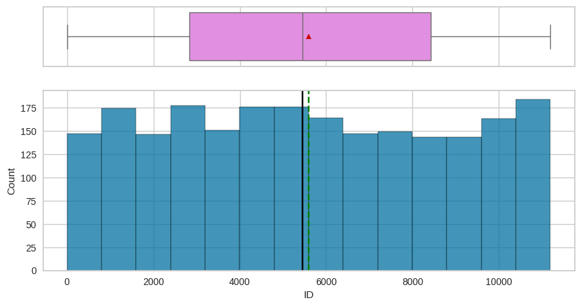

```python
# Generate histogram and boxplot for ID variable
histogram_boxplot(data, 'ID')
```

The boxplot does not show any outlier markers.

The histogram shows a relatively even spread across the range of IDs, which suggests the ID values are likely randomly or sequentially assigned. From the data dictionary we know each of these values in unique and so can be dropped from further analysis.

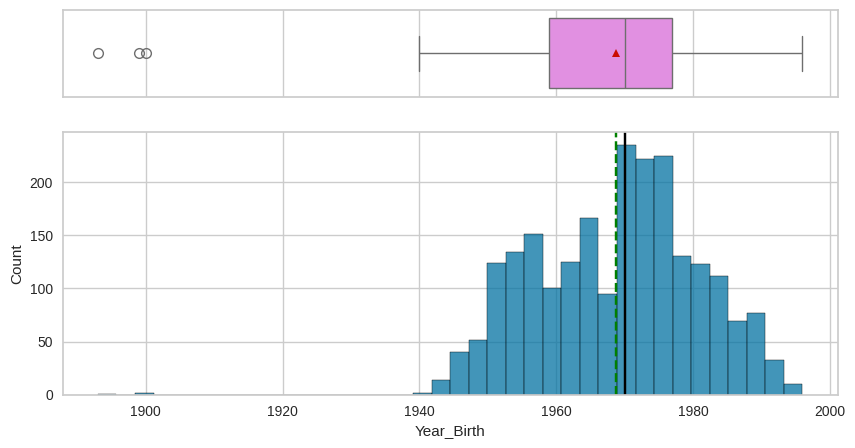

```python
# Generate histogram and boxplot for Year_Birth variable
histogram_boxplot(data, 'Year_Birth')
```

The distribution is slightly left-skewed and there are more younger customers than older ones. The majority of customers were born between 1950 and 1980. There are a few outliers that appear before 1920 that can be elliminated. Median year of birth is 1970.

```python
#Encode Education Variable Pt.1

#Check unique values and spelling for Education values
data['Education'].unique()
```

```
array(['Graduation', 'PhD', 'Master', 'Basic', '2n Cycle'], dtype=object)
```

```python
#Encode Education Variable Pt.2
edu_order = {
    'Basic': 0,
    '2n Cycle': 1,
    'Graduation': 2,
    'Master': 3,
    'PhD': 4
}

data['Education_Level'] = data['Education'].map(edu_order)
```

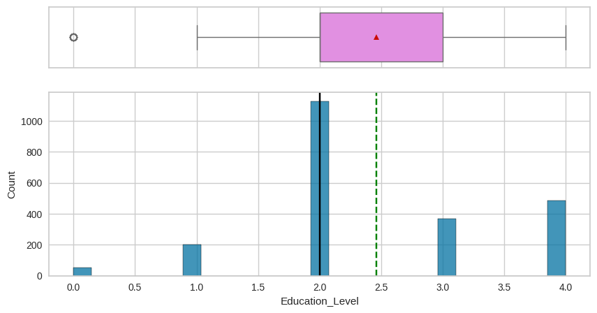

```python
# Generate histogram and boxplot for encoded Education_Level variable
histogram_boxplot(data, 'Education_Level')
```

Dominate eduation group is Graduation while Basic is very low.

```python
#Encode Marital_Status Pt.1

#Check unique values and spelling for Marital_Status values
data['Marital_Status'].unique()
```

```
array(['Single', 'Together', 'Married', 'Divorced', 'Widow', 'Alone',
       'Absurd', 'YOLO'], dtype=object)
```

```python
# Group martital status
marital_map = {
    'Married': 'Partnered',
    'Together': 'Partnered',
    'Single': 'Single',
    'Divorced': 'Single',
    'Widow': 'Single',
    'Alone': 'Single',
    'YOLO': 'Other',
    'Absurd': 'Other'
}

data['Marital_Status_Grouped'] = data['Marital_Status'].map(marital_map)
```

```python
#Encode Marital_Status Pt.2
#Drop "other"
data = pd.get_dummies(data, columns=['Marital_Status_Grouped'], prefix='Marital', drop_first=False)
```

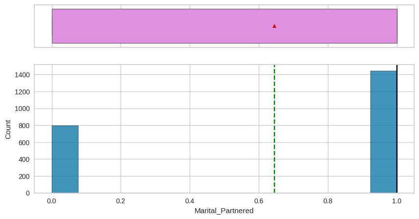

```python
# Generate histogram and boxplot for encoded Marital_Pertnered variable
histogram_boxplot(data, 'Marital_Partnered')
```

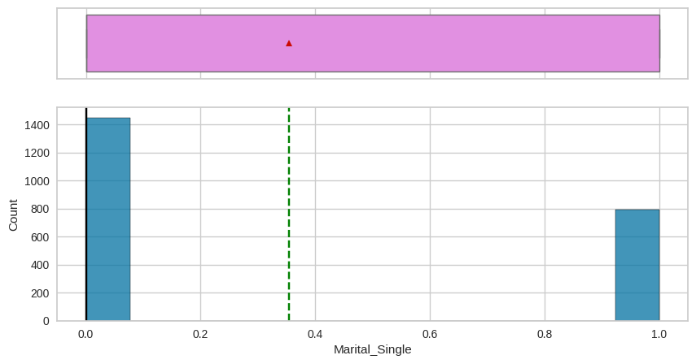

```python
# Generate histogram and boxplot for encoded Marital_Single variable
histogram_boxplot(data, 'Marital_Single')
```

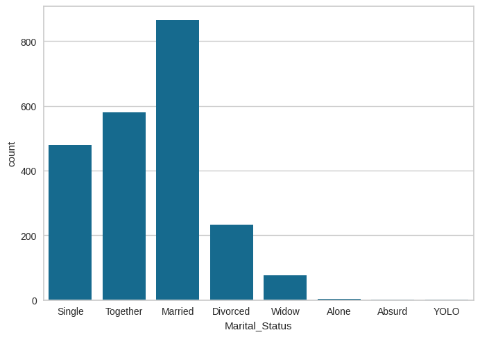

```python
# Generate countplot for pre-encoded Marital_Status variable
sns.countplot(data=data, x='Marital_Status')
```

Majority of entries are for those in partner relationships

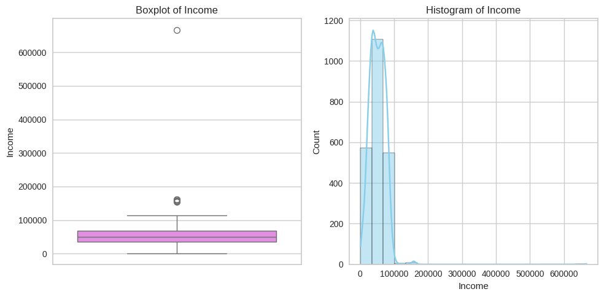

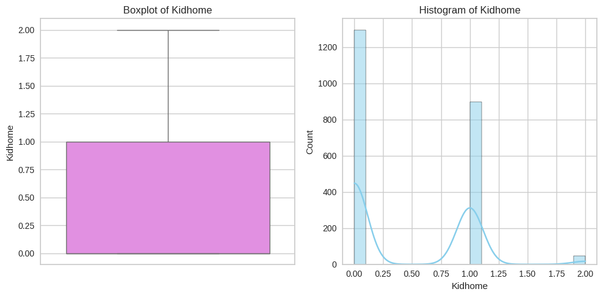

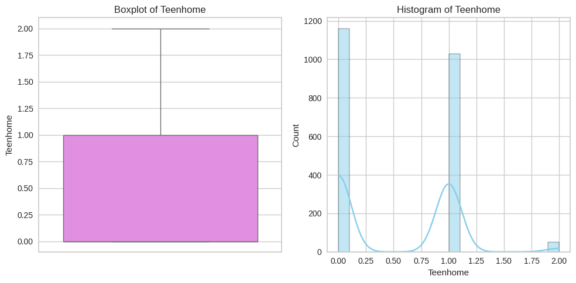

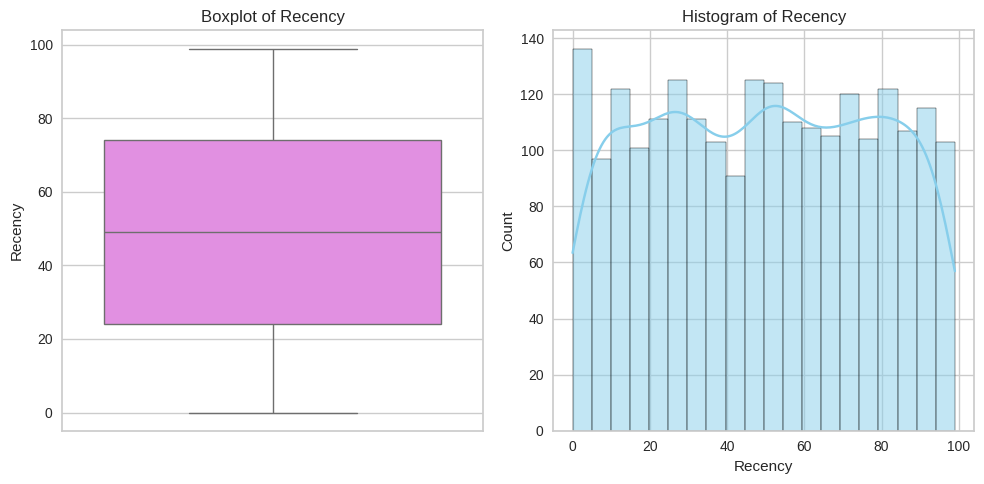

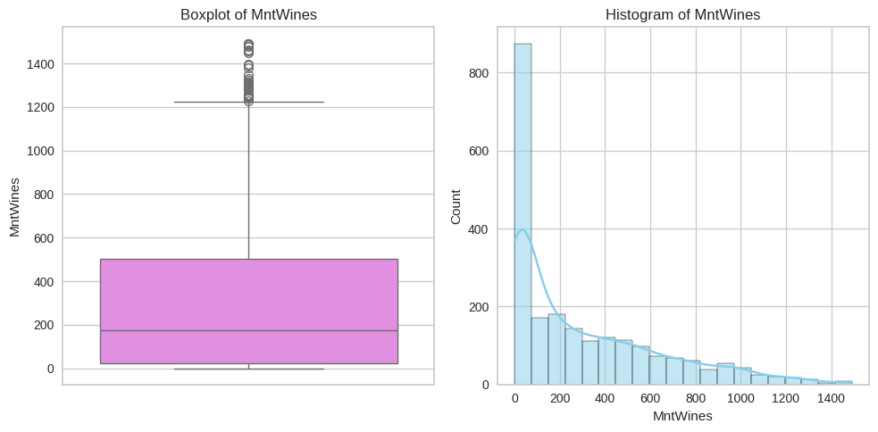

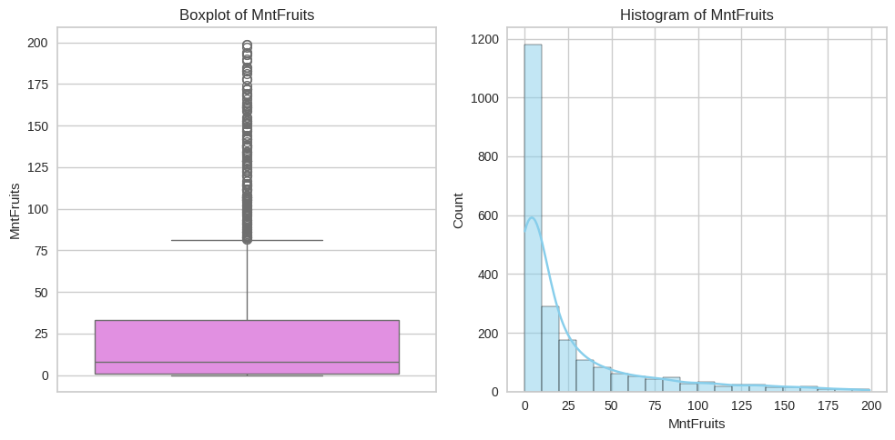

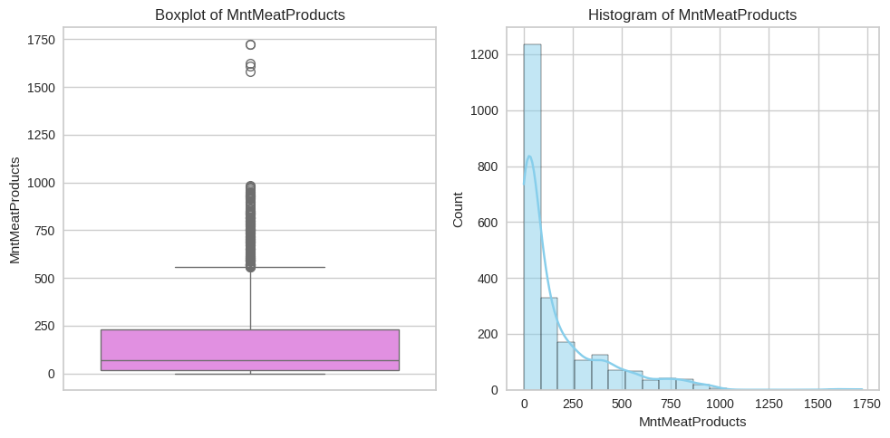

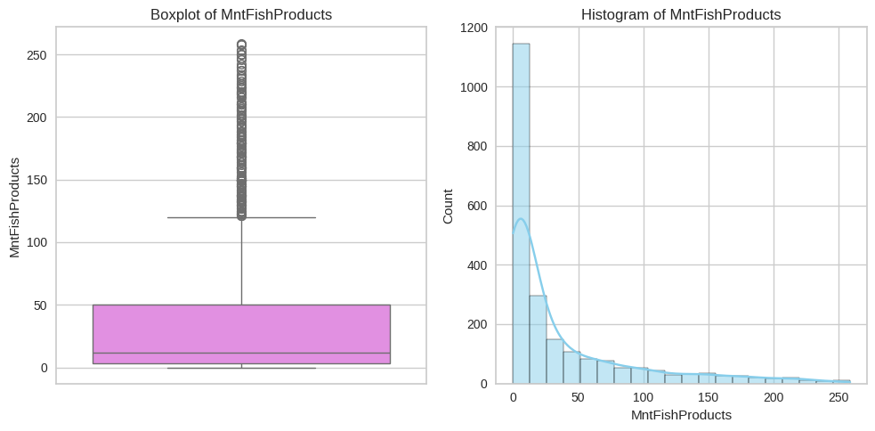

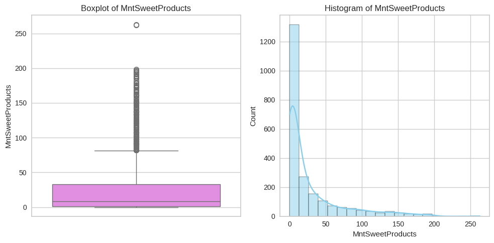

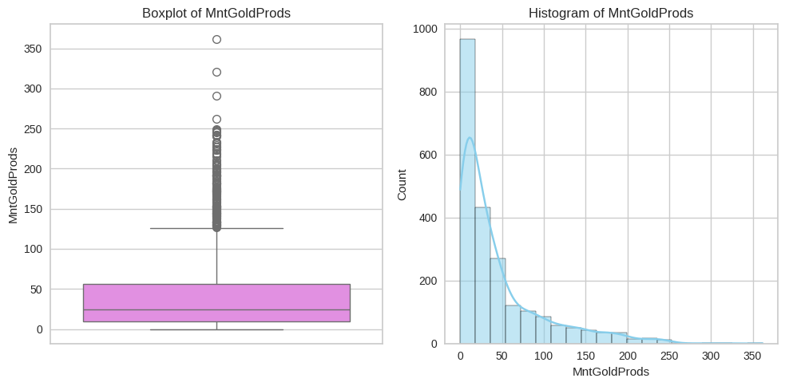

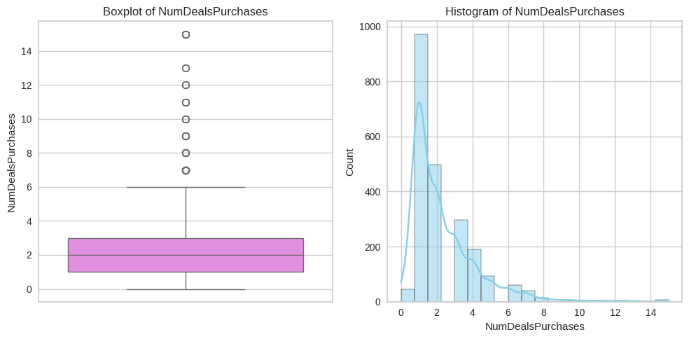

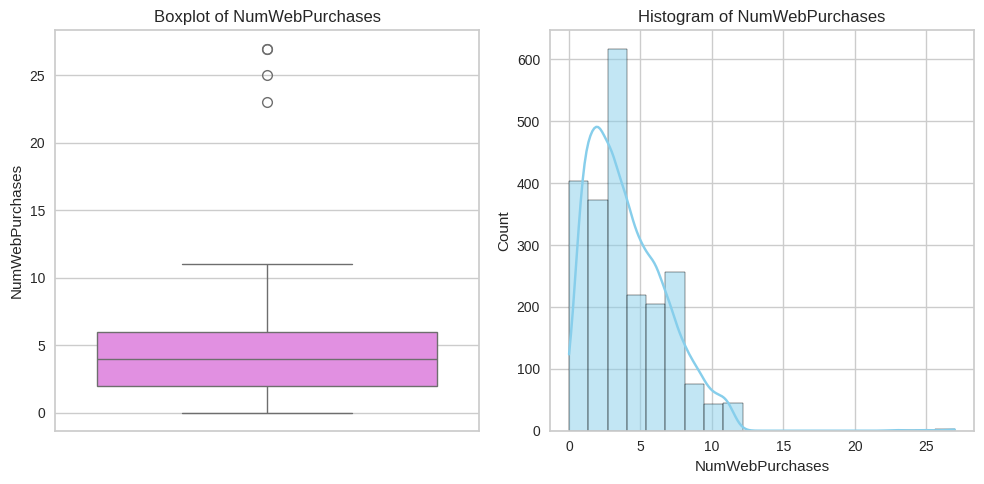

[13 more figures not shown]

```python
# Generate histograms/ boxplot for remaining numeric variables

#Fist select numeric columns only
numeric_cols = data.select_dtypes(include=['int64', 'float64']).columns

#Exclude ID and Year_Birth as these were previously ploted
cols_to_plot = numeric_cols.drop(['ID', 'Year_Birth'])


#Code to generate histograms and boxplots
for col in cols_to_plot:
    plt.figure(figsize=(10, 5))

    # Boxplot
    plt.subplot(1, 2, 1)
    sns.boxplot(data[col], color='violet')
    plt.title(f'Boxplot of {col}')

    # Histogram
    plt.subplot(1, 2, 2)
    sns.histplot(data[col], kde=True, bins=20, color='skyblue')
    plt.title(f'Histogram of {col}')

    plt.tight_layout()
    plt.show()
```

##### **Observations:**

- ID can be removed from further analysis as each value will be unique.
- Outliners in Year_Birth should be removed.
- Dominate education group is Graduation
- Majority of entries are for those in partner relationships
- Income is heavily right skewed and outliers should be removed.
- Majority of Repones was "No"
- Majority have not made a complaint
- Majority did not respond to campaigns
- Majority of web visits rage from 2.5-7.5 with outliers that can be removed in the upper ranges. Right skewed.
- Most make between 3-8 purchases in store, 0-5 catalog purchases and 1-6 Web  
  purchases. Meaning those in store purchase more.
- Wine generates the highest revenue and Fruits are lowest
- Most have between 0-1 teens and 0-1 kids
- Again Z_CostContact and Z_Revenue only have 1 value stored and so can be removed for analysis.

### Bivariate Analysis

#### **Question 6:** Perform multivariate analysis to explore the relationsips between the variables.

```python
# Prepare Data

#Select Numeric columns for scaling
data_for_scaling = data.select_dtypes(include=['int64', 'float64', 'uint8']).drop(columns=['ID','Z_CostContact','Z_Revenue'])

#Remove outlers mentioned in observations above
def remove_outliers(df, columns):
    mask = pd.Series([True] * len(df), index=df.index)
    for col in columns:
        Q1 = df[col].quantile(0.25)
        Q3 = df[col].quantile(0.75)
        IQR = Q3 - Q1
        lower = Q1 - 1.5 * IQR
        upper = Q3 + 1.5 * IQR
        mask &= (df[col] >= lower) & (df[col] <= upper)
    return df[mask]

cols_with_outliers = ['Income', 'Year_Birth', 'NumWebVisitsMonth']
data_no_outliers = remove_outliers(data_for_scaling, cols_with_outliers)


# Scale Data
scaler = StandardScaler()
data_scaled = scaler.fit_transform(data_no_outliers)
```

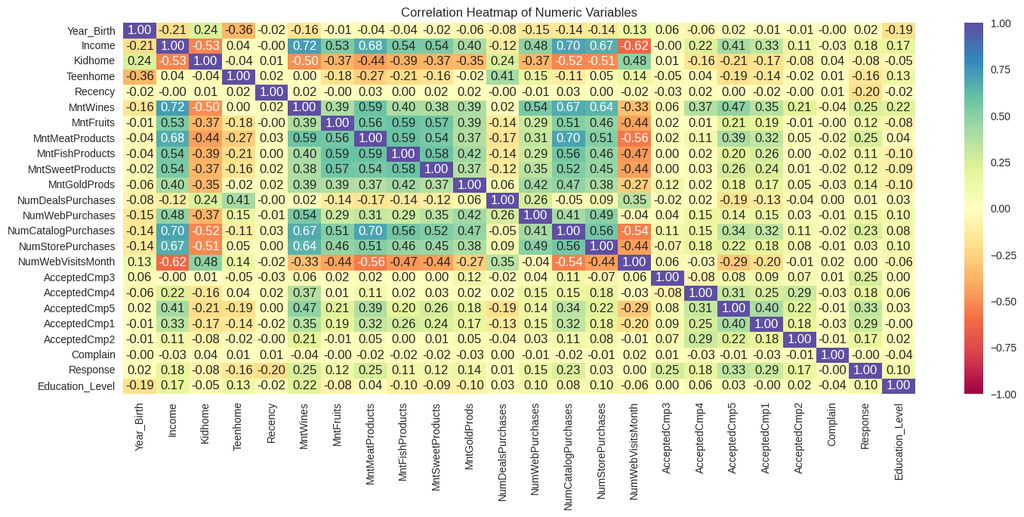

```python
# Check Data Correlation
cols_list = data_no_outliers.select_dtypes(include=np.number).columns.tolist()

# Set figure size
plt.figure(figsize=(15, 7))

# Plot heatmap of correlations
sns.heatmap(
    data_no_outliers[cols_list].corr(numeric_only=True),
    annot=True,
    vmin=-1,
    vmax=1,
    fmt=".2f",
    cmap="Spectral"
)

plt.title("Correlation Heatmap of Numeric Variables")
plt.tight_layout()
plt.show()
```

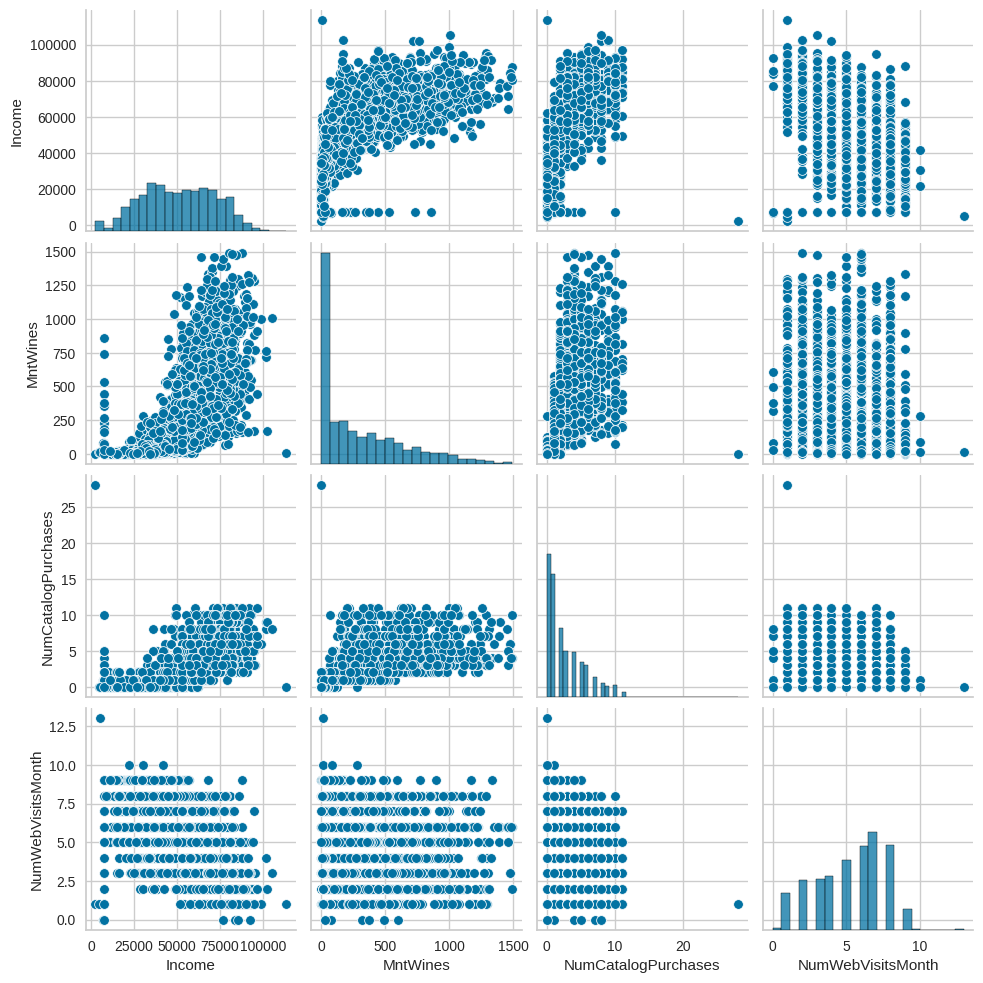

```python
# generate pairplot for variables with strong correleations
selected_cols = ['Income', 'MntWines', 'NumCatalogPurchases', 'NumWebVisitsMonth']
sns.pairplot(data_no_outliers[selected_cols])
```

## **K-means Clustering**

#### **Question 7** : Select the appropriate number of clusters using the elbow Plot. What do you think is the appropriate number of clusters?

- Correct number of clusters based on the elbow plot is 4. More detials in observations below.

```python
#Drop additional variables that are not useful for further analysis (i.e no strong correlations)
data_no_outliers_copy = data_no_outliers.drop([
    'AcceptedCmp3', 'AcceptedCmp4', 'AcceptedCmp5',
    'AcceptedCmp2', 'AcceptedCmp1', 'Year_Birth'
], axis=1)
```

```python
#Run Scaling again to account for dropped variables
# Scale Data
scaler = StandardScaler()
data_scaled = scaler.fit_transform(data_no_outliers_copy)
```

```python
k_means = data_no_outliers_copy.copy()
```

```
Clusters: 2 	WCSS: 28704.67
Number of Clusters: 2 	WCSS: 26661.726184471212
Clusters: 3 	WCSS: 25361.70
Number of Clusters: 3 	WCSS: 26661.726184471212
Clusters: 4 	WCSS: 23233.56
Number of Clusters: 4 	WCSS: 26661.726184471212
Clusters: 5 	WCSS: 22112.16
Number of Clusters: 5 	WCSS: 26661.726184471212
Clusters: 6 	WCSS: 20999.15
Number of Clusters: 6 	WCSS: 26661.726184471212
Clusters: 7 	WCSS: 20086.56
Number of Clusters: 7 	WCSS: 26661.726184471212
Clusters: 8 	WCSS: 19405.11
Number of Clusters: 8 	WCSS: 26661.726184471212
Clusters: 9 	WCSS: 18633.75
Number of Clusters: 9 	WCSS: 26661.726184471212
Clusters: 10 	WCSS: 17951.52
Number of Clusters: 10 	WCSS: 26661.726184471212
```

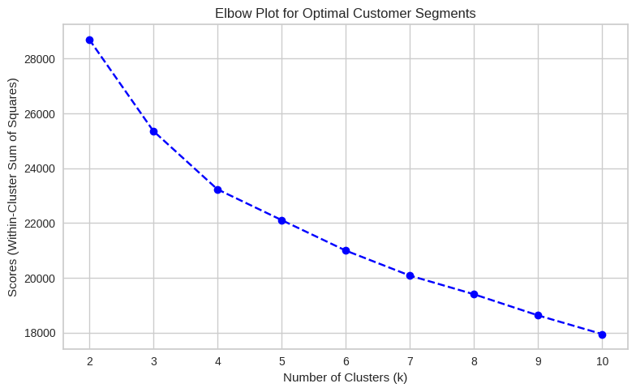

```python
cluster_range = range(2, 11)
scores = []

# Compute WCSS Scores for each value of k
for k in cluster_range:
    kmeans = KMeans(n_clusters=k, random_state=1, n_init=10)      # initialize K-means
    kmeans.fit(data_scaled)                                        # fit on the scaled data
    scores.append(kmeans.inertia_)
    print(f"Clusters: {k} \tWCSS: {kmeans.inertia_:.2f}")

    print("Number of Clusters:", k, "\tWCSS:", wcss)

# Plot elbow curve
plt.figure(figsize=(8, 5))
plt.plot(cluster_range, scores, marker='o', linestyle='--', color='blue')
plt.xlabel("Number of Clusters (k)")
plt.ylabel("Scores (Within-Cluster Sum of Squares)")
plt.title("Elbow Plot for Optimal Customer Segments", fontsize=12)
plt.grid(True)
plt.tight_layout()
plt.show()
```

##### **Observations:**

From k=2 ton k=4 the WCSS drops significatly but after k = 4 the elbow curve flattens out so including more clusters would have diminishing returns.

#### **Question 8** : finalize appropriate number of clusters by checking the silhoutte score as well. Is the answer different from the elbow plot?

*Based on the Silhouette scores k = 2 would give the best well defined clusters

```python
#Check Silhoutte fitting KMeans model
kmeans = KMeans(n_clusters=4, random_state=1, n_init=10)
labels = kmeans.fit_predict(data_scaled)

score = silhouette_score(data_scaled, labels)
for k in range(2, 11):
    kmeans = KMeans(n_clusters=k, random_state=1, n_init=10)
    labels = kmeans.fit_predict(data_scaled)
    score = silhouette_score(data_scaled, labels)
    print(f"k = {k}  →  Silhouette Score: {score:.4f}")
```

```
k = 2  →  Silhouette Score: 0.2864
k = 3  →  Silhouette Score: 0.2149
k = 4  →  Silhouette Score: 0.2267
k = 5  →  Silhouette Score: 0.1370
k = 6  →  Silhouette Score: 0.1336
k = 7  →  Silhouette Score: 0.1313
k = 8  →  Silhouette Score: 0.1375
k = 9  →  Silhouette Score: 0.1258
k = 10  →  Silhouette Score: 0.1359
```

##### **Observations:**

Based on the Silhouette scores k = 2 would give the best well defined clusters as it has the highest value. k = 4 would give more granualr segmentation but cause overlap

```python
# Final KMeans model with 2 clusers
final_kmeans = KMeans(n_clusters=2, random_state=1, n_init=10)

# Fit the model on the newly scaled data
final_labels = final_kmeans.fit_predict(data_scaled)

# Cluster labels
data_no_outliers_copy['Cluster'] = final_labels

# Cluster counts
print(data_no_outliers_copy['Cluster'].value_counts())

#Add in cluster summary
cluster_summary = data_no_outliers_copy.groupby('Cluster').mean(numeric_only=True)
display(cluster_summary)
```

```
Cluster
0    1306
1     915
Name: count, dtype: int64
```

| Cluster | Income | Kidhome | Teenhome | Recency | MntWines | MntFruits | MntMeatProducts | MntFishProducts | MntSweetProducts | MntGoldProds | NumDealsPurchases | NumWebPurchases | NumCatalogPurchases | NumStorePurchases | NumWebVisitsMonth | Complain | Response | Education_Level |
| --- | --- | --- | --- | --- | --- | --- | --- | --- | --- | --- | --- | --- | --- | --- | --- | --- | --- | --- |
| 0 | 37872.552067 | 0.710567 | 0.556662 | 48.849158 | 102.045176 | 6.269525 | 37.662328 | 9.322358 | 6.359112 | 22.238132 | 2.553599 | 2.938744 | 0.856049 | 3.915008 | 6.413476 | 0.009954 | 0.098009 | 2.388974 |
| 1 | 70496.151913 | 0.065574 | 0.438251 | 49.489617 | 597.016393 | 55.201093 | 348.759563 | 78.374863 | 57.068852 | 75.401093 | 1.956284 | 5.791257 | 5.200000 | 8.569399 | 3.684153 | 0.007650 | 0.225137 | 2.554098 |

##### **Observations:**

- Cluster 0: Lower engament, lower income group
1. Significatly lower income with lower purchaing rates across all channels as well as low spending across all categories
2. Higher webvisits but lower spending means they browse more but make less purchases.
- Cluster 1: Higher income, higher spending group
1. Almost double the income of cluster 0 with higher spending in all categories and across all channels
2. Most purcases made in store
3. Higher response rate
4. Fewer children in the home

## **Cluster Profiling and Comparison**

#### **Question 10**: Perform cluster profiling using boxplots for the K-Means algorithm. Analyze key characteristics of each cluster and provide detailed observations.

```python
# Select number columns
numeric_cols = [col for col in data_no_outliers_copy.select_dtypes(include='number').columns if col != 'Cluster']
```

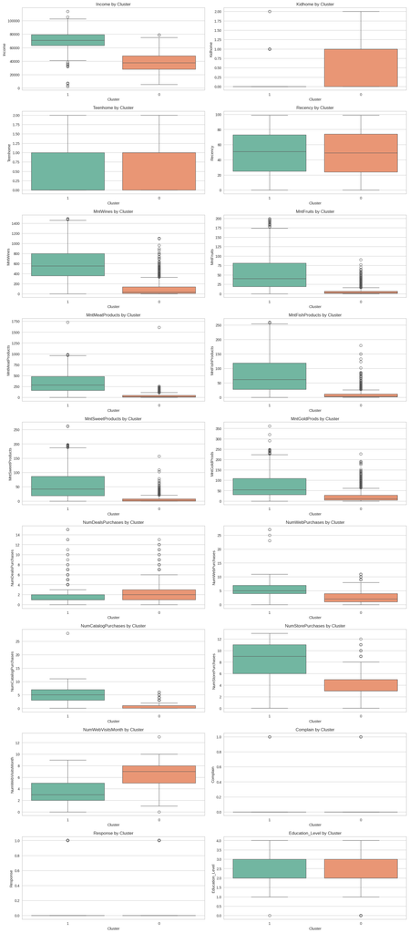

```python
# Cast Cluster as string for plotting
data_no_outliers_copy['Cluster'] = data_no_outliers_copy['Cluster'].astype(str)

# Generate boxplots
plt.figure(figsize=(16, len(numeric_cols) * 4))
for i, col in enumerate(numeric_cols, 1):
    plt.subplot(len(numeric_cols), 2, i)
    sns.boxplot(x='Cluster', y=col, data=data_no_outliers_copy, palette='Set2')
    plt.title(f'{col} by Cluster')
    plt.tight_layout()

plt.show()
```

##### **Observations:**

Cluster 0: Lower income homes with more children. They have a high browsing rate but low purchase rate leaning towards families on a budget.

Cluster 1: Higher income household that value high levels of service and tend towards an in person shopping experience.

- Cluster 0 has a lower income vs cluster 1
- Cluster 0 has more children but the same number of teens Recency of purchases does not change across the clusters
- Cluster 1 has higher purchases across Wines, Meat, Fish, Produce Sweets and Gold.
- Cluster 1 may be more responsive to marketing as seen in their higher correlation to response
- Cluster 0 looks for more deals comparatively as well as browses more online, but makes fewer purchases

#### **Question 11**: Perform cluster profiling on the data using a barplot for the K-Means algorithm. Provide insights and key observations for each cluster based on the visual analysis.

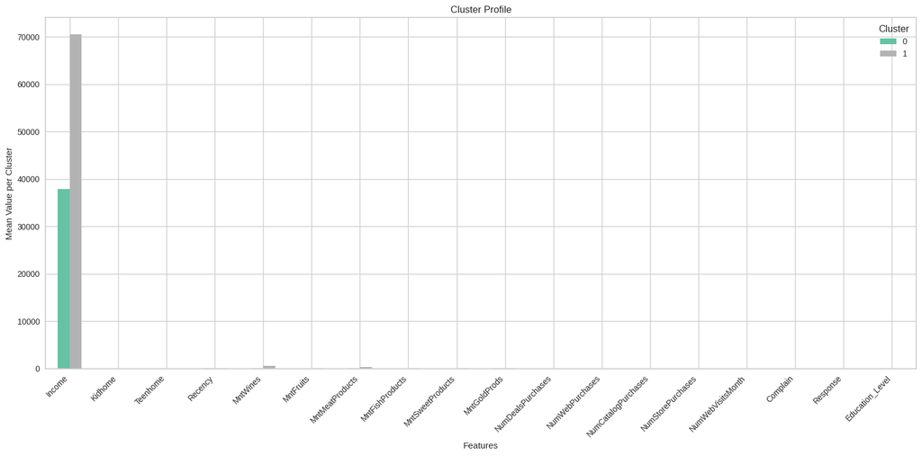

```python
# Calculate the mean
cluster_summary = data_no_outliers_copy.groupby('Cluster').mean(numeric_only=True)

# Add Variables to x-axis
cluster_summary_t = cluster_summary.T

# Generate Bar Plot
plt.figure(figsize=(16, len(cluster_summary_t) * 0.5))
cluster_summary_t.plot(kind='bar', figsize=(16, 8), colormap='Set2')

plt.title('Cluster Profile')
plt.ylabel('Mean Value per Cluster')
plt.xlabel('Features')
plt.xticks(rotation=45, ha='right')
plt.legend(title='Cluster')
plt.tight_layout()
plt.show()
```

##### **Observations:**

*Cluster 1 has more income and more engaged with purchases posing higher profitability

*Wine and meat generates the most proft in cluster 1

*Cluster 1 prefers to shop in store

## **Business Recommedations**

#### **Question 12**: Based on the cluster insights, what business recommendations can be provided?

Focus on Cluster 1: High Value, Highly Engaged Customers Focus on targeting those in Cluster 1 as they are much more profitable. More effective to have campaigns in store where they are more likely to see and engage with them. High revenue products like wine should be front and center to encourage purchasing them. The presence of younger children in cluster 0 tends to them being newer families that do have the potential to evolve into cluster 1 if they can be retained long enough. Specific recommendations include

1. VIP Loyalty Program: Exclusive early access, premium rewards, or concierge services to retain and grow this segment.
2. Upselling Opportunities: Introduce new or premium product lines — this group is likely to respond to high-end offerings.
3. While Cluster 1 prefers instore shopping it would be worthwhile to advertise digitally as well to nature cluster 0 into cluster 1